# PROMiDAT: Ciencia de Datos con Python

Ph.D. Oldemar Rodríguez R.

# Deep Learning - Redes Neuronales

Paquetes necesarios

```python
import os
import mglearn
import numpy as np
import pandas as pd
```

**Una regresión es una Red Neuronal de una Capa**

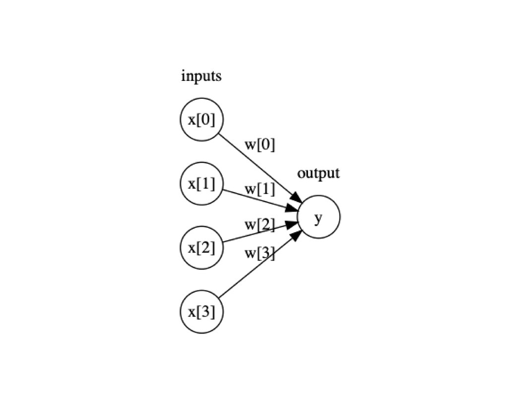

```python
mglearn.plots.plot_logistic_regression_graph()
```

**Red Neuronal con una Capa Oculta**

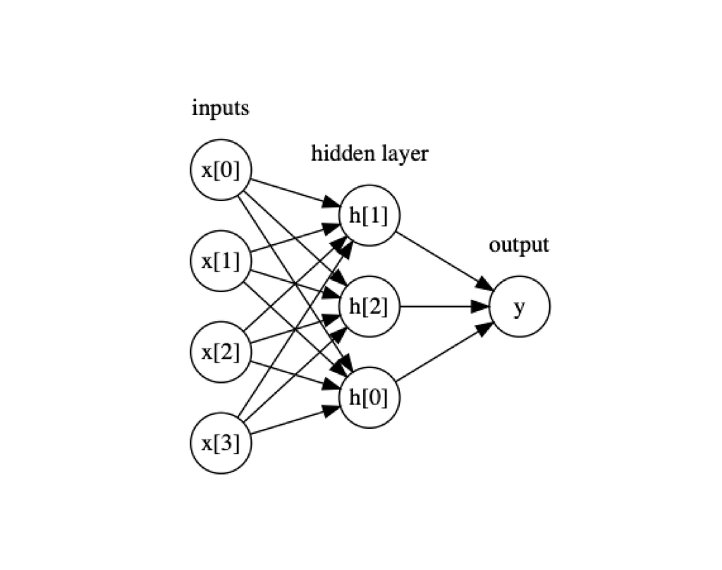

```python
mglearn.plots.plot_single_hidden_layer_graph()
```

# Deep Learning - Redes Neuronales con Tensor Flow y Keras

# Instrucciones para instalación de librerías TensorFlow y Keras:

Correr lo siguiente en el terminal:

Instalar TensorFlow: *pip install tensorflow*

Instalar Keras: *sudo pip install keras*

# Paquetes necesarios

```python
from keras.models import Sequential
from keras.layers import Dense
from sklearn.model_selection import train_test_split
from sklearn.metrics import confusion_matrix
from sklearn.preprocessing import MinMaxScaler
```

# Ejemplo con Datos Iris

*Cargamos datos*

```python
datos = pd.read_csv('/Users/promidat07/Proyectos/Python/Keras Python/Datos/iris.csv', delimiter = ';', decimal = ".")
print(datos.shape)
```

```
## (150, 5)
```

```python
print(datos.head())
```

```
##    s.largo  s.ancho  p.largo  p.ancho    tipo
## 0      5.1      3.5      1.4      0.2  setosa
## 1      4.9      3.0      1.4      0.2  setosa
## 2      4.7      3.2      1.3      0.2  setosa
## 3      4.6      3.1      1.5      0.2  setosa
## 4      5.0      3.6      1.4      0.2  setosa
```

```python
print(datos.info())
```

```
## <class 'pandas.core.frame.DataFrame'>
## RangeIndex: 150 entries, 0 to 149
## Data columns (total 5 columns):
## s.largo    150 non-null float64
## s.ancho    150 non-null float64
## p.largo    150 non-null float64
## p.ancho    150 non-null float64
## tipo       150 non-null object
## dtypes: float64(4), object(1)
## memory usage: 5.9+ KB
## None
```

*Elimina la variable catégorica, deja las variables predictoras en X*

```python
X = datos.iloc[:, :4]
print(X.head())
```

```
##    s.largo  s.ancho  p.largo  p.ancho
## 0      5.1      3.5      1.4      0.2
## 1      4.9      3.0      1.4      0.2
## 2      4.7      3.2      1.3      0.2
## 3      4.6      3.1      1.5      0.2
## 4      5.0      3.6      1.4      0.2
```

*Deja la variable a predecir en y*

```python
y = datos.iloc[:, 4]
print(y.head())
```

```
## 0    setosa
## 1    setosa
## 2    setosa
## 3    setosa
## 4    setosa
## Name: tipo, dtype: object
```

*Código disyundivo completo para variable a predecir*

```python
dummy_y = pd.get_dummies(y)
```

*Reescalamos variables predictoras entre 0 y 1*

```python
scaler = MinMaxScaler(feature_range = (0, 1))
scaled_X  = pd.DataFrame(scaler.fit_transform(X), columns = list(X))
```

*Con el 70% de los datos para entrenamiento*

```python
X_train, X_test, y_train, y_test = train_test_split(scaled_X, dummy_y, train_size = 0.7, random_state = 0)
print(X_train.head())
```

```
##       s.largo   s.ancho   p.largo   p.ancho
## 60   0.194444  0.000000  0.423729  0.375000
## 116  0.611111  0.416667  0.762712  0.708333
## 144  0.666667  0.541667  0.796610  1.000000
## 119  0.472222  0.083333  0.677966  0.583333
## 108  0.666667  0.208333  0.813559  0.708333
```

```python
print(X_test.head())
```

```
##       s.largo   s.ancho   p.largo   p.ancho
## 114  0.416667  0.333333  0.694915  0.958333
## 62   0.472222  0.083333  0.508475  0.375000
## 33   0.333333  0.916667  0.067797  0.041667
## 107  0.833333  0.375000  0.898305  0.708333
## 7    0.194444  0.583333  0.084746  0.041667
```

```python
print(y_train.head())
```

```
##      setosa  versicolor  virginica
## 60        0           1          0
## 116       0           0          1
## 144       0           0          1
## 119       0           0          1
## 108       0           0          1
```

```python
print(y_test.head())
```

```
##      setosa  versicolor  virginica
## 114       0           0          1
## 62        0           1          0
## 33        1           0          0
## 107       0           0          1
## 7         1           0          0
```

*Creamos el modelo en Keras*

Los modelos en Keras son definidos como una secuencia de capas. Creamos un modelo secuencial (que es el más común) y agregamos capas una a una. Capas totalmente conectadas se definen usando la clase Dense. Para la primera capa usa la función de activación *relu*, y para la capa output se usa *softmax*. *softmax* se usa usa para asegurar que el output estén en el rango de 0 a 1 y se puedan interpretar como probabilidades.

```python
model = Sequential()
model.add(Dense(10, input_dim = 4, activation = 'relu'))  # Agregamos primera capa oculta con 10 neuronas
model.add(Dense(8, activation = 'relu'))  # Agregamos segunda capa oculta con 8 neuronas
model.add(Dense(6, activation = 'relu'))  # Agregamos tercera capa oculta con 6 neuronas
model.add(Dense(3, activation = 'softmax')) # Agregamos capa output con 3 neuronas
```

*Compilamos el modelo*

Indicamos la diferentes funciones para ejecutar y evaluar el modelo. Como lo es la función de pérdida, el optimizador y las métricas de evaluación.

```python
model.compile(loss = 'categorical_crossentropy', optimizer = 'adam', metrics = ['accuracy'])
```

*Resumen del modelo*

```python
print(model.summary())
```

```
## _________________________________________________________________
## Layer (type)                 Output Shape              Param #
## =================================================================
## dense_1 (Dense)              (None, 10)                50
## _________________________________________________________________
## dense_2 (Dense)              (None, 8)                 88
## _________________________________________________________________
## dense_3 (Dense)              (None, 6)                 54
## _________________________________________________________________
## dense_4 (Dense)              (None, 3)                 21
## =================================================================
## Total params: 213
## Trainable params: 213
## Non-trainable params: 0
## _________________________________________________________________
## None
```

*Ajustamos el modelo*

Usamos 100 etapas de entrenamiento (*epochs*) y actualizando los pesos de la red cada 10 observaciones procesadas (*batch_size*).

```python
model.fit(X_train, y_train, epochs = 100, batch_size = 10, verbose = 0)
```

*Corremos predicción sobre los datos de testing*

```python
# La predicción es una matriz con 3 columnas
y_pred = model.predict(X_test)
# Convertimos a columna
y_test_class = np.argmax(np.asanyarray(y_test), axis = 1)  # Convertimos a array
y_pred_class = np.argmax(y_pred, axis = 1)
```

*Evaluamos el modelo*

```python
scores = model.evaluate(X_test, y_test)
print(model.metrics_names[1], scores[1])
```

```
## acc 0.9777777791023254
```

## Matriz de confusión

```python
MC = confusion_matrix(y_test_class, y_pred_class)
print(MC)
```

```
## [[16  0  0]
##  [ 0 17  1]
##  [ 0  0 11]]
```

## Índices de calidad

```python
def indices_general(MC, nombres = None):
    precision_global = np.sum(MC.diagonal()) / np.sum(MC)
    error_global = 1 - precision_global
    precision_categoria  = pd.DataFrame(MC.diagonal()/np.sum(MC,axis = 1)).T
    if nombres!=None:
        precision_categoria.columns = nombres
    return {"Matriz de Confusión":MC,
            "Precisión Global":precision_global,
            "Error Global":error_global,
            "Precisión por Categoría":precision_categoria}

indices = indices_general(MC,list(np.unique(y)))
for k in indices:
    print("\n%s:\n%s"%(k,str(indices[k])))
```

```
##
## Matriz de Confusión:
## [[16  0  0]
##  [ 0 17  1]
##  [ 0  0 11]]
##
## Precisión Global:
## 0.9777777777777777
##
## Error Global:
## 0.022222222222222254
##
## Precisión por Categoría:
##    setosa  versicolor  virginica
## 0     1.0    0.944444        1.0
```

# Cambiando Cantidad de Capas Ocultas

**Usando una cantidad diferente capas ocultas y de nodos**

**Usando 5 capas ocultas de 10 nodos cada una**

```python
#Creamos Modelo
model = Sequential()
model.add(Dense(10, input_dim = 4, activation = 'relu'))
model.add(Dense(10, activation = 'relu'))
model.add(Dense(10, activation = 'relu'))
model.add(Dense(10, activation = 'relu'))
model.add(Dense(10, activation = 'relu'))
model.add(Dense(3, activation = 'softmax'))
# Compilamos modelo
model.compile(loss = 'categorical_crossentropy', optimizer = 'adam', metrics = ['accuracy'])
# Resumen
print(model.summary())
# Ajustamos modelo
```

```
## _________________________________________________________________
## Layer (type)                 Output Shape              Param #
## =================================================================
## dense_5 (Dense)              (None, 10)                50
## _________________________________________________________________
## dense_6 (Dense)              (None, 10)                110
## _________________________________________________________________
## dense_7 (Dense)              (None, 10)                110
## _________________________________________________________________
## dense_8 (Dense)              (None, 10)                110
## _________________________________________________________________
## dense_9 (Dense)              (None, 10)                110
## _________________________________________________________________
## dense_10 (Dense)             (None, 3)                 33
## =================================================================
## Total params: 523
## Trainable params: 523
## Non-trainable params: 0
## _________________________________________________________________
## None
```

```python
model.fit(X_train, y_train, epochs = 100, batch_size = 10, verbose = 0)
```

*Corremos predicción sobre los datos de testing*

```python
# La predicción es una matriz con 3 columnas
y_pred = model.predict(X_test)
# Convertimos a columna
y_test_class = np.argmax(np.asanyarray(y_test), axis = 1)  # Convertimos a array
y_pred_class = np.argmax(y_pred, axis = 1)
```

*Evaluamos el modelo*

```python
scores = model.evaluate(X_test, y_test)
print(model.metrics_names[1], scores[1])
```

```
## acc 0.9555555568801032
```

## Matriz de confusión

```python
MC = confusion_matrix(y_test_class, y_pred_class)
print(MC)
```

```
## [[16  0  0]
##  [ 0 17  1]
##  [ 0  1 10]]
```

## Índices de calidad

```python
def indices_general(MC, nombres = None):
    precision_global = np.sum(MC.diagonal()) / np.sum(MC)
    error_global = 1 - precision_global
    precision_categoria  = pd.DataFrame(MC.diagonal()/np.sum(MC,axis = 1)).T
    if nombres!=None:
        precision_categoria.columns = nombres
    return {"Matriz de Confusión":MC,
            "Precisión Global":precision_global,
            "Error Global":error_global,
            "Precisión por Categoría":precision_categoria}

indices = indices_general(MC, list(np.unique(y)))
for k in indices:
    print("\n%s:\n%s"%(k,str(indices[k])))
```

```
##
## Matriz de Confusión:
## [[16  0  0]
##  [ 0 17  1]
##  [ 0  1 10]]
##
## Precisión Global:
## 0.9555555555555556
##
## Error Global:
## 0.0444444444444444
##
## Precisión por Categoría:
##    setosa  versicolor  virginica
## 0     1.0    0.944444   0.909091
```

*Observación. Para un problema sencillo el usar muchas capas ocultas o muchas neuronas podrían generar sobreajuste, lo cual genera una reducción en el poder predictivo*

# Ejemplo con Datos Scoring

*Cargamos datos*

```python
datos = pd.read_csv('/Users/promidat07/Proyectos/Python/Keras Python/Datos/MuestraCredito5000V2.csv', delimiter = ';')
print(datos.shape)
```

```
## (5000, 6)
```

```python
print(datos.head())
```

```
##    MontoCredito  IngresoNeto     ...      GradoAcademico BuenPagador
## 0         14327            1     ...           Bachiller          Si
## 1        111404            1     ...           Bachiller          Si
## 2         21128            1     ...           Bachiller          Si
## 3         15426            2     ...           Bachiller          Si
## 4         10351            1     ...           Bachiller          Si
##
## [5 rows x 6 columns]
```

```python
print(datos.info())
```

```
## <class 'pandas.core.frame.DataFrame'>
## RangeIndex: 5000 entries, 0 to 4999
## Data columns (total 6 columns):
## MontoCredito         5000 non-null int64
## IngresoNeto          5000 non-null int64
## CoefCreditoAvaluo    5000 non-null int64
## MontoCuota           5000 non-null object
## GradoAcademico       5000 non-null object
## BuenPagador          5000 non-null object
## dtypes: int64(3), object(3)
## memory usage: 234.5+ KB
## None
```

```python
# Estas variables están como números sin embargo son categorías
datos['IngresoNeto'] = datos['IngresoNeto'].astype('category')
datos['CoefCreditoAvaluo'] = datos['CoefCreditoAvaluo'].astype('category')
```

*Elimina la variable catégorica, deja las variables predictoras en X*

```python
X = datos.iloc[:, :5]
print(X.head())
```

```
##    MontoCredito IngresoNeto      ...       MontoCuota GradoAcademico
## 0         14327           1      ...          MuyBajo      Bachiller
## 1        111404           1      ...          MuyBajo      Bachiller
## 2         21128           1      ...          MuyBajo      Bachiller
## 3         15426           2      ...          MuyBajo      Bachiller
## 4         10351           1      ...          MuyBajo      Bachiller
##
## [5 rows x 5 columns]
```

*Deja la variable a predecir en y*

```python
y = datos.iloc[:, 5]
print(y.head())
```

```
## 0    Si
## 1    Si
## 2    Si
## 3    Si
## 4    Si
## Name: BuenPagador, dtype: object
```

*Código disyundivo completo para variables*

```python
dummy_X = pd.get_dummies(X)
dummy_y = pd.get_dummies(y).loc[:, 'Si']  # Basta tomar la variable Si
```

*Reescalamos variables predictoras entre 0 y 1*

```python
scaler = MinMaxScaler(feature_range = (0, 1))
scaled_dummy_X = pd.DataFrame(scaler.fit_transform(dummy_X), columns = list(dummy_X))
```

*Con el 80% de los datos para entrenamiento*

```python
X_train, X_test, y_train, y_test = train_test_split(scaled_dummy_X, dummy_y, train_size = 0.8, random_state = 0)
print(X_train.head())
```

```
##       MontoCredito             ...               GradoAcademico_Licenciatura
## 2913      0.813022             ...                                       0.0
## 3275      0.038909             ...                                       0.0
## 775       0.153469             ...                                       0.0
## 217       0.097014             ...                                       0.0
## 1245      0.000892             ...                                       1.0
##
## [5 rows x 21 columns]
```

```python
print(X_test.head())
```

```
##       MontoCredito             ...               GradoAcademico_Licenciatura
## 398       0.136487             ...                                       1.0
## 3833      0.013321             ...                                       1.0
## 4836      0.059592             ...                                       0.0
## 4572      0.031005             ...                                       1.0
## 636       0.032316             ...                                       0.0
##
## [5 rows x 21 columns]
```

```python
print(y_train.head())
```

```
## 2913    1
## 3275    1
## 775     1
## 217     1
## 1245    1
## Name: Si, dtype: uint8
```

```python
print(y_test.head())
```

```
## 398     1
## 3833    1
## 4836    0
## 4572    1
## 636     1
## Name: Si, dtype: uint8
```

*Creamos el modelo en Keras*

```python
model = Sequential()
model.add(Dense(16, input_dim = 21, activation = 'relu'))  # Agregamos primera capa oculta
model.add(Dense(10, activation = 'relu'))  # Agregamos segunda capa oculta
model.add(Dense(5, activation = 'relu'))  # Agregamos tercera capa oculta
model.add(Dense(1, activation = 'sigmoid')) # Agregamos capa output
```

*Compilamos el modelo*

```python
model.compile(loss = 'binary_crossentropy', optimizer = 'adam', metrics = ['accuracy'])
```

*Resumen del modelo*

```python
print(model.summary())
```

```
## _________________________________________________________________
## Layer (type)                 Output Shape              Param #
## =================================================================
## dense_11 (Dense)             (None, 16)                352
## _________________________________________________________________
## dense_12 (Dense)             (None, 10)                170
## _________________________________________________________________
## dense_13 (Dense)             (None, 5)                 55
## _________________________________________________________________
## dense_14 (Dense)             (None, 1)                 6
## =================================================================
## Total params: 583
## Trainable params: 583
## Non-trainable params: 0
## _________________________________________________________________
## None
```

*Ajustamos el modelo*

```python
model.fit(X_train, y_train, epochs = 100, batch_size = 50, verbose = 0)
```

*Corremos predicción sobre los datos de testing*

```python
y_pred = np.round(model.predict(X_test))  # Redondeamos pues obtenemos un número entre 0 y 1
```

*Evaluamos el modelo*

```python
scores = model.evaluate(X_test, y_test)
print(model.metrics_names[1], scores[1])
```

```
## acc 0.954
```

## Matriz de confusión

```python
MC = confusion_matrix(y_test, y_pred)
print(MC)
```

```
## [[ 78  40]
##  [  6 876]]
```

## Índices de calidad

```python
indices = indices_general(MC)
for k in indices:
    print("\n%s:\n%s"%(k,str(indices[k])))
```

```
##
## Matriz de Confusión:
## [[ 78  40]
##  [  6 876]]
##
## Precisión Global:
## 0.954
##
## Error Global:
## 0.04600000000000004
##
## Precisión por Categoría:
##           0         1
## 0  0.661017  0.993197
```